# Sustainability in Fashion

Reese Putnam

2025-01-24

In this project we will find the countrys with the best sustanbile fashion brands and if they have recycling prgram efforts to sustain their production.

```r
install.packages("tidyverse")
```

```r
install.packages("ggplot2")
install.packages("dplyr")
install.packages("tidyr")
library(tidyverse)
library(ggplot2)
library(dplyr)
library(tidyr)
```

```r
data <- read_csv("sustainable_fashion_trends.csv")
```

The data we are using is the sustainable fashion trends data set found for free on Kaggle. This data set has 5000 rows and 15 columns showing various insights on brands and their usuage of resources to create their clothing. We will use this data set to see which cpuntry’s have the most sustainable brands and what resources they use to creat their clothing that contributes to their sustainability.

```r
str(data)
```

```
## spc_tbl_ [5,000 × 15] (S3: spec_tbl_df/tbl_df/tbl/data.frame)
##  $ Brand_ID                  : chr [1:5000] "BRAND-0001" "BRAND-0002" "BRAND-0003" "BRAND-0004" ...
##  $ Brand_Name                : chr [1:5000] "Brand_1" "Brand_2" "Brand_3" "Brand_4" ...
##  $ Country                   : chr [1:5000] "Australia" "Japan" "USA" "Italy" ...
##  $ Year                      : num [1:5000] 2018 2015 2024 2023 2016 ...
##  $ Sustainability_Rating     : chr [1:5000] "D" "D" "A" "D" ...
##  $ Material_Type             : chr [1:5000] "Tencel" "Vegan Leather" "Vegan Leather" "Bamboo Fabric" ...
##  $ Eco_Friendly_Manufacturing: chr [1:5000] "No" "Yes" "No" "No" ...
##  $ Carbon_Footprint_MT       : num [1:5000] 1.75 124.39 336.66 152.04 415.63 ...
##  $ Water_Usage_Liters        : num [1:5000] 4511153 1951566 467455 899577 1809220 ...
##  $ Waste_Production_KG       : num [1:5000] 97844 37268 38386 32665 37295 ...
##  $ Recycling_Programs        : chr [1:5000] "No" "No" "No" "No" ...
##  $ Product_Lines             : num [1:5000] 2 15 2 13 19 10 17 18 11 9 ...
##  $ Average_Price_USD         : num [1:5000] 38.3 250.1 146.2 165.5 211.6 ...
##  $ Market_Trend              : chr [1:5000] "Growing" "Growing" "Growing" "Stable" ...
##  $ Certifications            : chr [1:5000] "GOTS" "GOTS" "B Corp" "OEKO-TEX" ...
##  - attr(*, "spec")=
##   .. cols(
##   ..   Brand_ID = col_character(),
##   ..   Brand_Name = col_character(),
##   ..   Country = col_character(),
##   ..   Year = col_double(),
##   ..   Sustainability_Rating = col_character(),
##   ..   Material_Type = col_character(),
##   ..   Eco_Friendly_Manufacturing = col_character(),
##   ..   Carbon_Footprint_MT = col_double(),
##   ..   Water_Usage_Liters = col_double(),
##   ..   Waste_Production_KG = col_double(),
##   ..   Recycling_Programs = col_character(),
##   ..   Product_Lines = col_double(),
##   ..   Average_Price_USD = col_double(),
##   ..   Market_Trend = col_character(),
##   ..   Certifications = col_character()
##   .. )
##  - attr(*, "problems")=<externalptr>
```

```r
summary(data)
```

```
##    Brand_ID          Brand_Name          Country               Year
##  Length:5000        Length:5000        Length:5000        Min.   :2010
##  Class :character   Class :character   Class :character   1st Qu.:2013
##  Mode  :character   Mode  :character   Mode  :character   Median :2017
##                                                           Mean   :2017
##                                                           3rd Qu.:2021
##                                                           Max.   :2024
##  Sustainability_Rating Material_Type      Eco_Friendly_Manufacturing
##  Length:5000           Length:5000        Length:5000
##  Class :character      Class :character   Class :character
##  Mode  :character      Mode  :character   Mode  :character
##
##
##
##  Carbon_Footprint_MT Water_Usage_Liters Waste_Production_KG Recycling_Programs
##  Min.   :  1.04      Min.   :  50106    Min.   : 1026       Length:5000
##  1st Qu.:126.61      1st Qu.:1293087    1st Qu.:25341       Class :character
##  Median :250.65      Median :2499096    Median :50466       Mode  :character
##  Mean   :250.32      Mean   :2517862    Mean   :50107
##  3rd Qu.:372.25      3rd Qu.:3763860    3rd Qu.:74985
##  Max.   :499.93      Max.   :4999597    Max.   :99948
##  Product_Lines   Average_Price_USD Market_Trend       Certifications
##  Min.   : 1.00   Min.   : 20.02    Length:5000        Length:5000
##  1st Qu.: 5.00   1st Qu.:142.87    Class :character   Class :character
##  Median :10.00   Median :258.62    Mode  :character   Mode  :character
##  Mean   :10.43   Mean   :259.35
##  3rd Qu.:15.00   3rd Qu.:378.60
##  Max.   :20.00   Max.   :499.94
```

Now that we have seen the structre of our data set we first need to check if there is any missing values in the data set and remove if needed.

```r
colSums(is.na(data))
```

```
##                   Brand_ID                 Brand_Name
##                          0                          0
##                    Country                       Year
##                          0                          0
##      Sustainability_Rating              Material_Type
##                          0                          0
## Eco_Friendly_Manufacturing        Carbon_Footprint_MT
##                          0                          0
##         Water_Usage_Liters        Waste_Production_KG
##                          0                          0
##         Recycling_Programs              Product_Lines
##                          0                          0
##          Average_Price_USD               Market_Trend
##                          0                          0
##             Certifications
##                          0
```

As shown above we see there is no data missing in each column so we can begin analzing and visualizing the data.

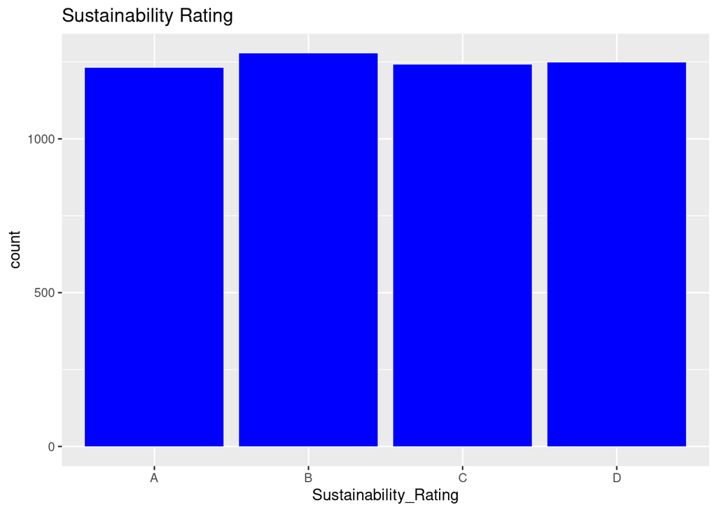

```r
ggplot(data, aes(x= Sustainability_Rating)) +
  geom_bar(fill= "blue") +
  ggtitle( "Sustainability Rating")
```

```r
country_ratings <- data %>%
  group_by( Country, Sustainability_Rating) %>%
  summarise(Count = n())
```

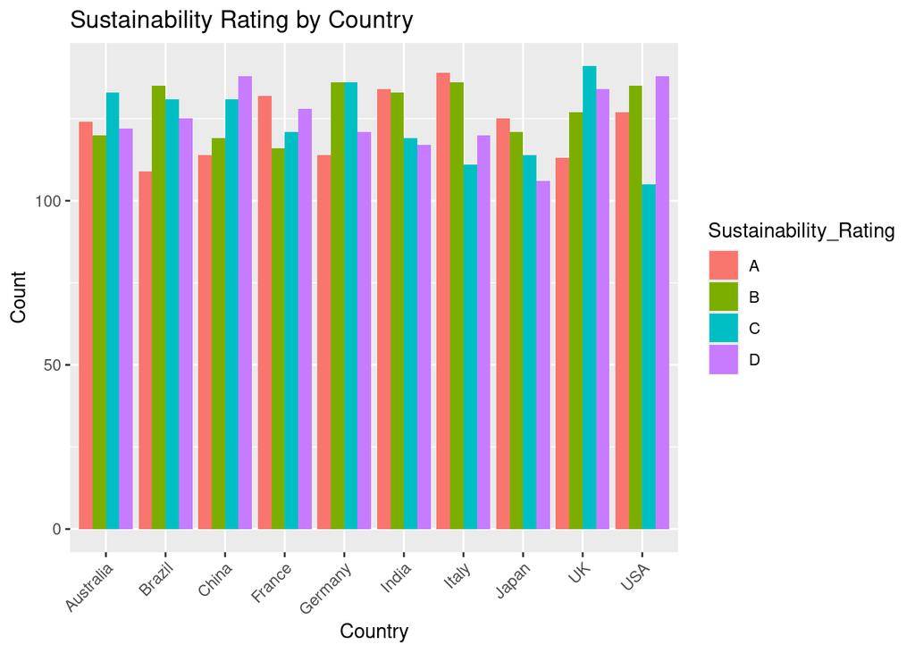

```r
ggplot(country_ratings, aes(x= Country,y= Count, fill= Sustainability_Rating))+
  geom_bar(stat="identity", position = "dodge")+
  ggtitle("Sustainability Rating by Country") +
  theme(axis.text.x = element_text(angle = 45, hjust = 1))
```

From the graph above we can observe that France, India, and Italy have the highest A sustainability rating compared to the other countrys.

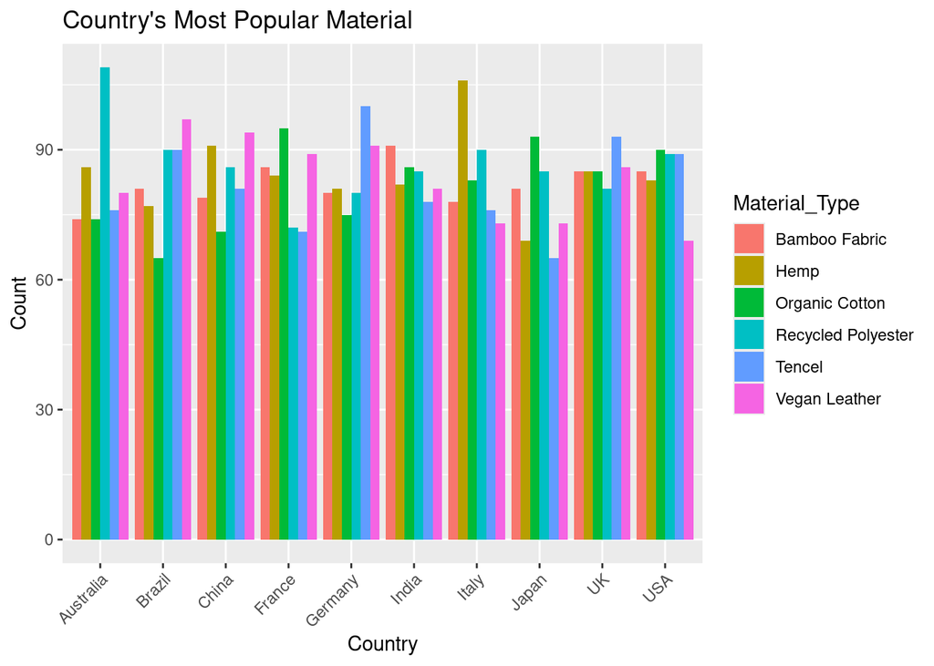

```r
ggplot(data, aes(x= Country, fill= Material_Type))+
  geom_bar(stat="Count", position= "dodge") +
  ggtitle("Country's Most Popular Material") +
  xlab("Country")+
  ylab("Count") +
  theme(axis.text.x = element_text(angle = 45, hjust = 1))
```

There shows to be a consistent use of all material expect for Australia having the most use of recycled polyester and Italy using Hemp.

```r
carbon_footprint <- data %>%
  group_by( Country, Carbon_Footprint_MT) %>%
  summarise(count= n())
```

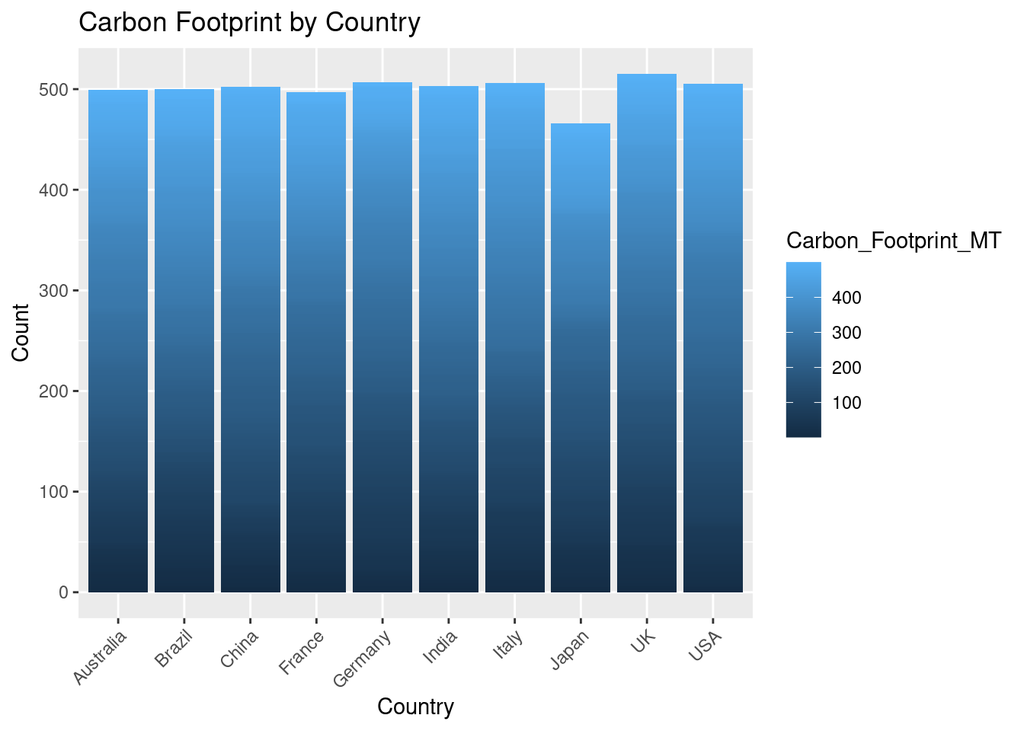

```r
ggplot(carbon_footprint, aes(x= Country, y= count, fill= Carbon_Footprint_MT))+
  geom_bar(stat="identity")+
  ggtitle("Carbon Footprint by Country")+
  xlab("Country")+
  ylab("Count")+
  theme(axis.text.x = element_text(angle = 45, hjust = 1))
```

```r
water_usage <- data %>%
  group_by(Country, Water_Usage_Liters) %>%
  summarise(count= n())
```

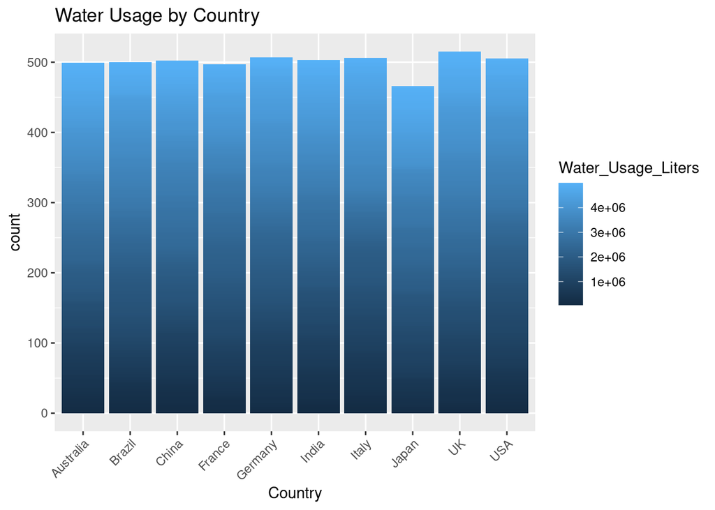

```r
ggplot(water_usage, aes(x= Country, y= count, fill= Water_Usage_Liters)) +
  geom_bar(stat= "identity", postion= "dodge")+
  ggtitle("Water Usage by Country")+
  theme(axis.text.x = element_text(angle = 45, hjust = 1))
```

```r
waste_production <- data %>%
  group_by(Country, Waste_Production_KG) %>%
  summarise(count = n())
```

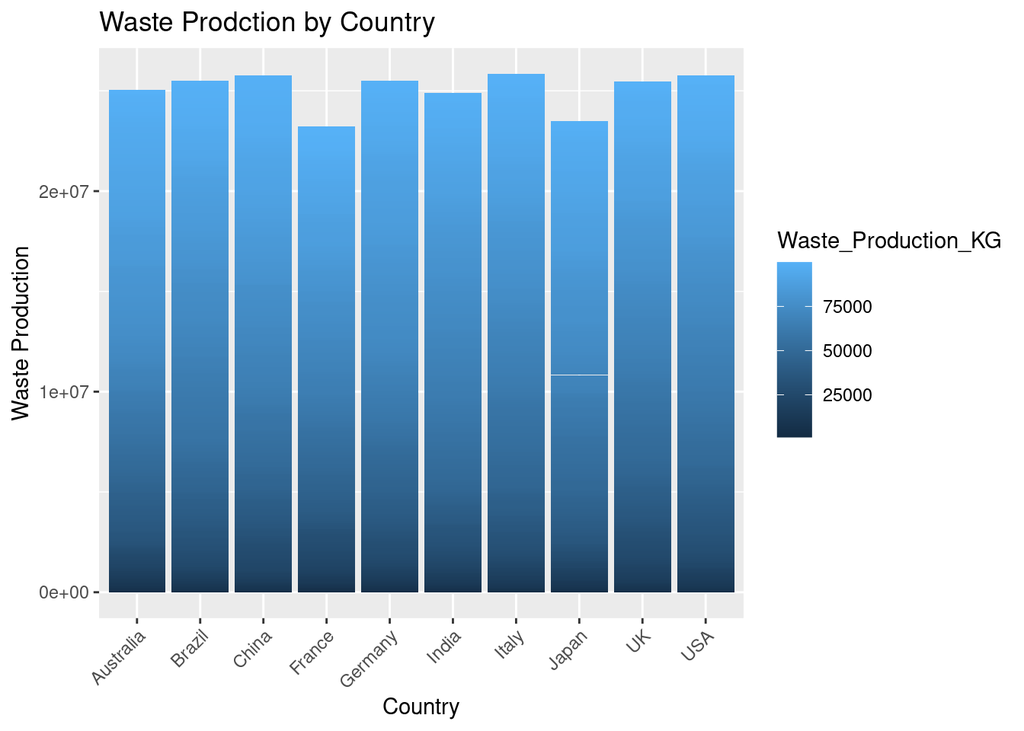

```r
ggplot(waste_production, aes(x=Country, y= Waste_Production_KG, fill= Waste_Production_KG))+
  geom_bar(stat= "identity", postion= "dodge")+
  ggtitle("Waste Prodction by Country")+
  xlab("Country")+
  ylab("Waste Production")+
  theme(axis.text.x = element_text(angle = 45, hjust = 1))
```

Now that we have compared the carbon footprint, water usuage, and waste prodution as factors that contribute to each country’s sustainability let’s see if price will show any contribution to that score as well.

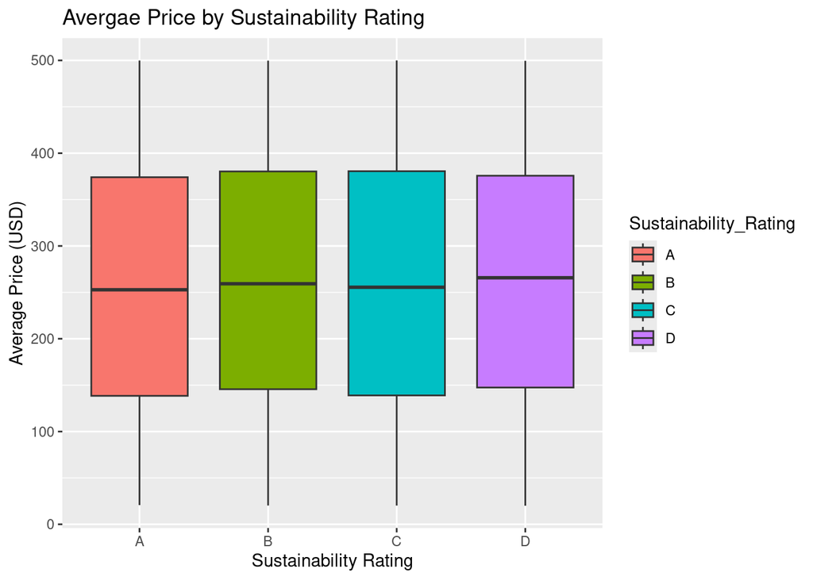

```r
ggplot(data, aes(x= Sustainability_Rating, y= Average_Price_USD, fill= Sustainability_Rating))+
  geom_boxplot()+
  ggtitle("Avergae Price by Sustainability Rating")+
  xlab("Sustainability Rating")+
  ylab("Average Price (USD)")
```

There isn’t any trend shown in the graph above assuming that price effects the sustainability of the country. So we will see if the certifications show any trend in sustainability

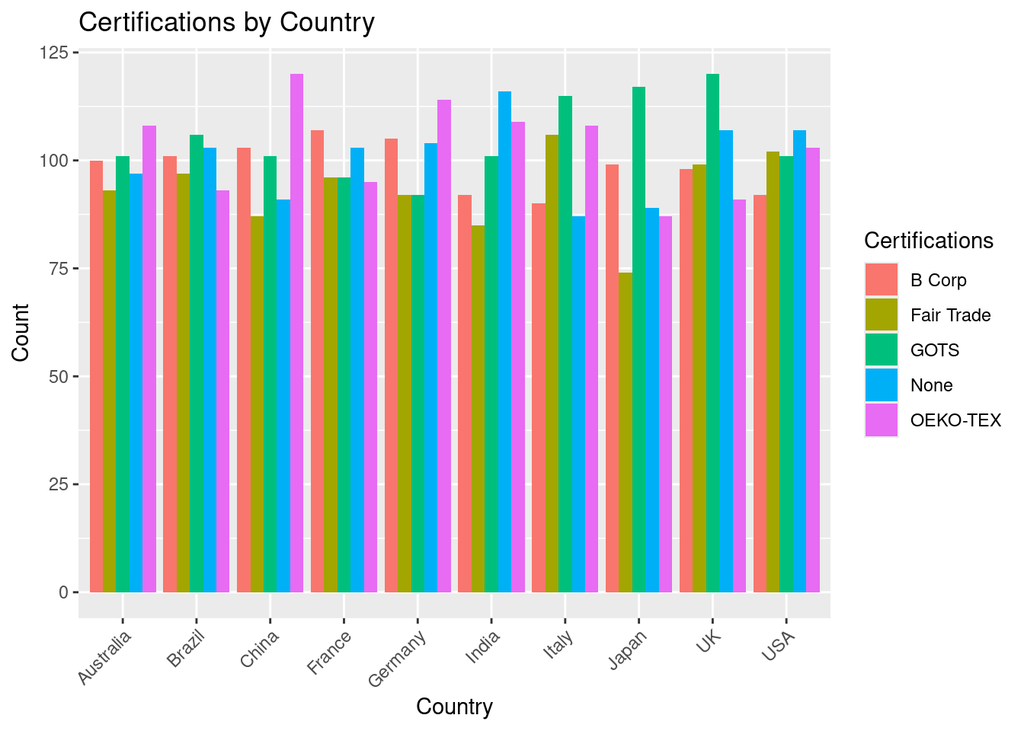

```r
ggplot(data, aes(x= Country, fill= Certifications))+
  geom_bar(stat= "Count", position= "dodge")+
  ggtitle("Certifications by Country")+
  xlab("Country")+
  ylab("Count")+
  theme(axis.text.x = element_text(angle = 45, hjust = 1))
```

Finally we will see which country’s have recycling programs in place.

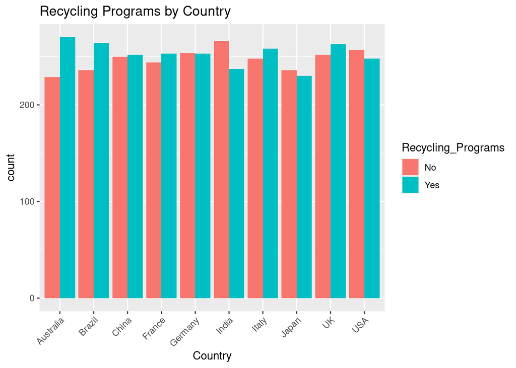

```r
ggplot(data, aes(x= Country, fill= Recycling_Programs))+
  geom_bar(stat="Count", position= "dodge")+
  ggtitle("Recycling Programs by Country")+
  theme(axis.text.x = element_text(angle = 45, hjust = 1))
```